# Logistic_regression

2025-01-15

Loading libraries

```r
library(tidyverse)
library(car)
library(pROC) # install
theme_set(theme_bw())
```

```r
data <- readxl::read_excel('data/burnout.xlsx')

str(data)
```

```
## tibble [467 × 8] (S3: tbl_df/tbl/data.frame)
##  $ burnout : chr [1:467] "Burnt Out" "Burnt Out" "Burnt Out" "Burnt Out" ...
##  $ loc     : num [1:467] 61.8 42.9 22.4 13.5 38.2 ...
##  $ cope    : num [1:467] 81.7 39.7 17.6 25.2 34.4 ...
##  $ teaching: num [1:467] 94.5 94.5 63.6 60 61.8 ...
##  $ research: num [1:467] 81.2 60.4 64.6 62.5 68.8 ...
##  $ pastoral: num [1:467] 96.3 87 68.5 66.7 61.1 ...
##  $ gender  : chr [1:467] "male" "male" "male" "male" ...
##  $ degree  : chr [1:467] "mba" "mba" "mba" "mba" ...
```

```r
# View(data)
```

```r
colnames(data)
```

```
## [1] "burnout"  "loc"      "cope"     "teaching" "research" "pastoral" "gender"
## [8] "degree"
```

```r
data$burnout <- ifelse(data$burnout=='Burnt Out', 1, 0)
model0 <- lm(burnout  ~ ., data)
summary(model0)
```

```
##
## Call:
## lm(formula = burnout ~ ., data = data)
##
## Residuals:
##      Min       1Q   Median       3Q      Max
## -0.90987 -0.19328 -0.06103  0.09642  0.95713
##
## Coefficients:
##              Estimate Std. Error t value Pr(>|t|)
## (Intercept) -0.123357   0.120321  -1.025  0.30579
## loc          0.013348   0.001487   8.975  < 2e-16 ***
## cope         0.017542   0.001342  13.075  < 2e-16 ***
## teaching    -0.011368   0.001863  -6.104 2.21e-09 ***
## research     0.001499   0.001119   1.340  0.18082
## pastoral     0.004323   0.001383   3.127  0.00188 **
## gendermale  -0.024839   0.032080  -0.774  0.43916
## degreems     0.020259   0.054946   0.369  0.71252
## degreephd    0.040350   0.044960   0.897  0.36995
## ---
## Signif. codes:  0 '***' 0.001 '**' 0.01 '*' 0.05 '.' 0.1 ' ' 1
##
## Residual standard error: 0.3403 on 458 degrees of freedom
## Multiple R-squared:  0.402,  Adjusted R-squared:  0.3915
## F-statistic: 38.48 on 8 and 458 DF,  p-value: < 2.2e-16
```

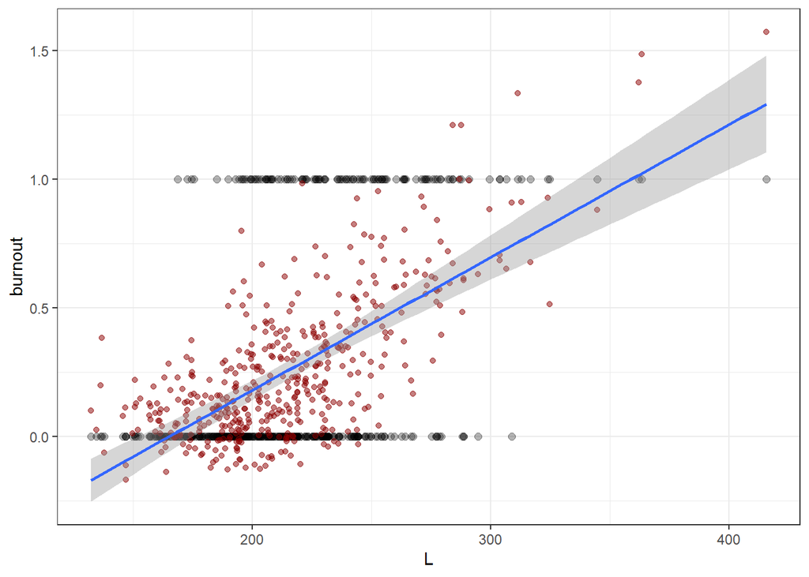

```r
data %>%
  mutate(
    L = loc + cope + teaching + research + pastoral
  ) %>%
  ggplot(aes(L, burnout)) +
  geom_point(size = 2, alpha = .3) +
  geom_point(aes(y = model0$fitted.values),
             color = 'darkred', alpha = 0.5) +
  geom_smooth(method='lm')
```

What is happening to the y-axis?..

### Let’s define a *Generalized* Linear Model (do not confuse with *General* linear models – we talked about them in the previous classes)

Pay attention to the argument “family” – we say that we want our model to assume that the data has a binomial distribution and ask it (the model) to use “logits”-transformation (“logit” linking function) to linearize our data

```r
model <- glm(burnout ~ ., data, family = binomial(link = 'logit'))
```

```r
summary(model)
```

```
##
## Call:
## glm(formula = burnout ~ ., family = binomial(link = "logit"),
##     data = data)
##
## Coefficients:
##             Estimate Std. Error z value Pr(>|z|)
## (Intercept) -4.53834    1.13985  -3.982 6.85e-05 ***
## loc          0.11067    0.01485   7.452 9.22e-14 ***
## cope         0.14143    0.01633   8.660  < 2e-16 ***
## teaching    -0.11166    0.01970  -5.669 1.44e-08 ***
## research     0.01956    0.01045   1.871 0.061292 .
## pastoral     0.04663    0.01324   3.521 0.000429 ***
## gendermale  -0.23010    0.29348  -0.784 0.433012
## degreems     0.09624    0.48884   0.197 0.843924
## degreephd    0.13788    0.40329   0.342 0.732424
## ---
## Signif. codes:  0 '***' 0.001 '**' 0.01 '*' 0.05 '.' 0.1 ' ' 1
##
## (Dispersion parameter for binomial family taken to be 1)
##
##     Null deviance: 530.11  on 466  degrees of freedom
## Residual deviance: 320.42  on 458  degrees of freedom
## AIC: 338.42
##
## Number of Fisher Scoring iterations: 6
```

How to interpret these results?

### Let’s consider the deviance and significant of our model

In order to assess significance of the model we need create a null-model and compare it’s quality to our custom model

Pay attention that in the previous class we used test=‘F’, while here test=‘Chi’

```r
model_null <- glm(burnout ~ 1, data, family = binomial(link = 'logit'))
anova(model_null, model, test = 'Chi')
```

```
## Analysis of Deviance Table
##
## Model 1: burnout ~ 1
## Model 2: burnout ~ loc + cope + teaching + research + pastoral + gender +
##     degree
##   Resid. Df Resid. Dev Df Deviance  Pr(>Chi)
## 1       466     530.11
## 2       458     320.42  8   209.68 < 2.2e-16 ***
## ---
## Signif. codes:  0 '***' 0.001 '**' 0.01 '*' 0.05 '.' 0.1 ' ' 1
```

Well done! our model is better that constant model!

Can we make our model simpler and better?

```r
drop1(model, test='Chi')
```

```
## Single term deletions
##
## Model:
## burnout ~ loc + cope + teaching + research + pastoral + gender +
##     degree
##          Df Deviance    AIC     LRT  Pr(>Chi)
## <none>        320.42 338.42
## loc       1   389.39 405.39  68.971 < 2.2e-16 ***
## cope      1   447.57 463.57 127.143 < 2.2e-16 ***
## teaching  1   359.67 375.67  39.247 3.735e-10 ***
## research  1   323.97 339.97   3.546 0.0596861 .
## pastoral  1   333.45 349.45  13.030 0.0003065 ***
## gender    1   321.04 337.04   0.616 0.4325692
## degree    2   320.54 334.54   0.119 0.9421006
## ---
## Signif. codes:  0 '***' 0.001 '**' 0.01 '*' 0.05 '.' 0.1 ' ' 1
```

```r
model2 <- update(model, . ~ . -degree)
```

```r
AIC(model); AIC(model2)
```

```
## [1] 338.4239
```

```
## [1] 334.5432
```

```r
anova(model, model2, test = 'Chi')
```

```
## Analysis of Deviance Table
##
## Model 1: burnout ~ loc + cope + teaching + research + pastoral + gender +
##     degree
## Model 2: burnout ~ loc + cope + teaching + research + pastoral + gender
##   Resid. Df Resid. Dev Df Deviance Pr(>Chi)
## 1       458     320.42
## 2       460     320.54 -2 -0.11929   0.9421
```

See if we can remove any other variable and check if it will not make the model worse

```r
# <your code goes here>
drop1(model2, test='Chi')
```

```
## Single term deletions
##
## Model:
## burnout ~ loc + cope + teaching + research + pastoral + gender
##          Df Deviance    AIC     LRT  Pr(>Chi)
## <none>        320.54 334.54
## loc       1   389.41 401.41  68.862 < 2.2e-16 ***
## cope      1   448.07 460.07 127.525 < 2.2e-16 ***
## teaching  1   359.83 371.83  39.282 3.667e-10 ***
## research  1   324.22 336.22   3.677 0.0551516 .
## pastoral  1   333.56 345.56  13.022 0.0003079 ***
## gender    1   321.20 333.20   0.655 0.4181722
## ---
## Signif. codes:  0 '***' 0.001 '**' 0.01 '*' 0.05 '.' 0.1 ' ' 1
```

```r
model3 <- update(model2, . ~ . -gender)
anova(model2, model3)
```

```
## Analysis of Deviance Table
##
## Model 1: burnout ~ loc + cope + teaching + research + pastoral + gender
## Model 2: burnout ~ loc + cope + teaching + research + pastoral
##   Resid. Df Resid. Dev Df Deviance Pr(>Chi)
## 1       460     320.54
## 2       461     321.20 -1 -0.65545   0.4182
```

```r
AIC(model3); AIC(model2)
```

```
## [1] 333.1986
```

```
## [1] 334.5432
```

```r
drop1(model3, test='Chi')
```

```
## Single term deletions
##
## Model:
## burnout ~ loc + cope + teaching + research + pastoral
##          Df Deviance    AIC     LRT  Pr(>Chi)
## <none>        321.20 333.20
## loc       1   389.96 399.96  68.758 < 2.2e-16 ***
## cope      1   449.32 459.32 128.125 < 2.2e-16 ***
## teaching  1   360.42 370.42  39.225 3.777e-10 ***
## research  1   324.71 334.71   3.511 0.0609503 .
## pastoral  1   333.71 343.71  12.512 0.0004042 ***
## ---
## Signif. codes:  0 '***' 0.001 '**' 0.01 '*' 0.05 '.' 0.1 ' ' 1
```

```r
model4 <- update(model3, . ~ . -research)
anova(model3, model4)
```

```
## Analysis of Deviance Table
##
## Model 1: burnout ~ loc + cope + teaching + research + pastoral
## Model 2: burnout ~ loc + cope + teaching + pastoral
##   Resid. Df Resid. Dev Df Deviance Pr(>Chi)
## 1       461     321.20
## 2       462     324.71 -1  -3.5113  0.06095 .
## ---
## Signif. codes:  0 '***' 0.001 '**' 0.01 '*' 0.05 '.' 0.1 ' ' 1
```

```r
AIC(model3); AIC(model4)
```

```
## [1] 333.1986
```

```
## [1] 334.71
```

Let’s check model assumptions:::

1. multicollinearity

```r
car::vif(model4)
```

```
##      loc     cope teaching pastoral
## 1.754591 2.636453 3.653513 1.398286
```

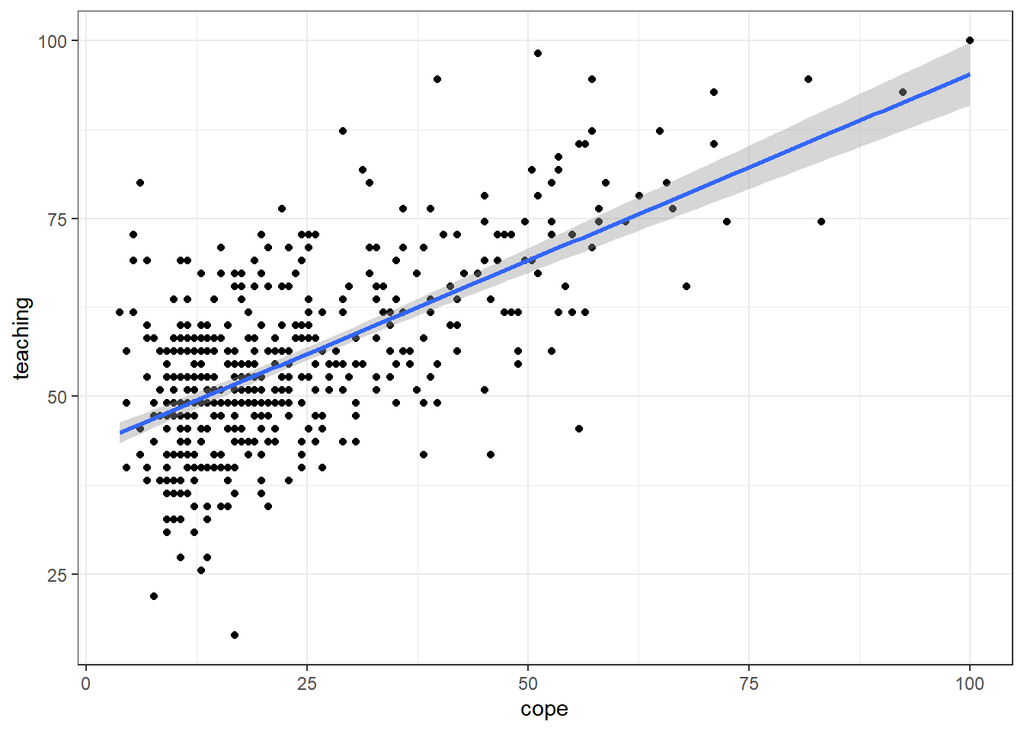

```r
ggplot(data, aes(cope, teaching)) +
  geom_point() +
  geom_smooth(method='lm')
```

2. Distribution of residuals::

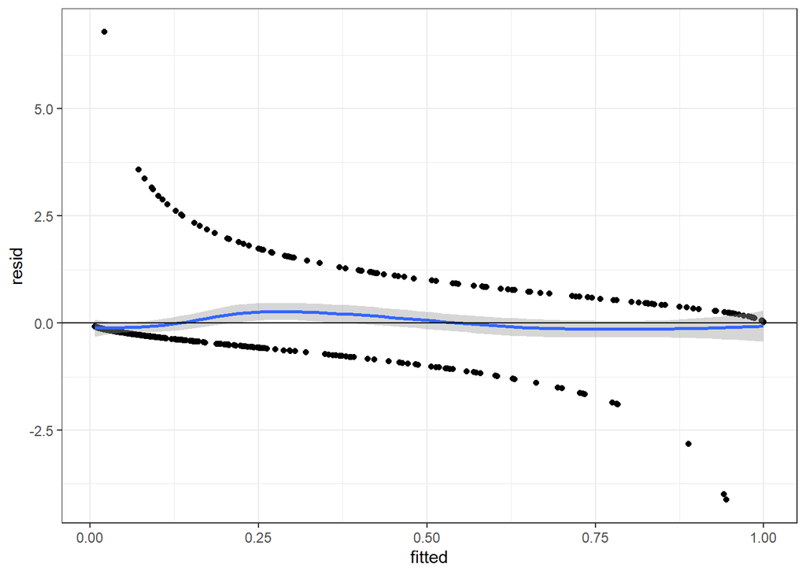

```r
logdiag <- tibble(fitted = fitted(model4, type = 'response'),
                  resid = resid(model4, type = 'pearson'))

logdiag %>% ggplot(aes(fitted, resid)) +
  geom_point() +
  geom_smooth(method='loess') +
  geom_hline(yintercept = 0)
```

there definitely are some outliers

3. “Heteroscedasticity”

```r
pchisq(sum(residuals(model4, type = "deviance")^2), model4$df.residual)
```

```
## [1] 2.331353e-07
```

if the result of the test is > .05, then NO heteroscedasticity is in the model

## How to interpret model coefficients?

```r
result <- summary(model4)
coefs <- as.data.frame(result$coefficients)
coefs$Odds_ratio <- exp(coefs$Estimate)
coefs$`Pr(>|z|)` <- ifelse(coefs$`Pr(>|z|)` < .05, '*', '')

coefs
```

```
##                Estimate Std. Error   z value Pr(>|z|) Odds_ratio
## (Intercept) -3.02321076 0.74701260 -4.047068        * 0.04864478
## loc          0.10668384 0.01471318  7.250902        * 1.11258245
## cope         0.13540566 0.01562971  8.663348        * 1.14500117
## teaching    -0.11011230 0.01956954 -5.626720        * 0.89573354
## pastoral     0.04376716 0.01289666  3.393681        * 1.04473907
```

**NB!** Pay attention to the Odds_ratio and p-value

1. Intercept: in general (with all the other conditions being equal) a person is less likely to experience burnout (the odds is 4.86%)
2. loc: if loc is increased by one unit, the odds of a person of experiencing burnout is increased by 11.26%
3. cope: if cope is increased by one unit, the odds of a person of experiencing burnout is increased by 14.5%
4. teaching: if teaching is increased by one unit, the odds of a person of experiencing burnout is *decreased* by 10.43%
5. pastoral: if pastoral is increased by one unit, the odds of a person of experiencing burnout is increased by 4.47%

## Model quality assessment

P.S. print(‘hello, machine learning!’)

Divide sample into train and test

```r
set.seed(5432)
ind_train <- sample(1:nrow(data), size = 0.8 * nrow(data), replace = FALSE)
data %>%
  slice(ind_train) -> data_train
data %>%
  slice(-ind_train) -> data_test
```

Use *train* dataset to fit your model (find the best coefficients), use *test* dataset to test your model’s quality of classification

```r
str(data)
```

```
## tibble [467 × 8] (S3: tbl_df/tbl/data.frame)
##  $ burnout : num [1:467] 1 1 1 1 1 1 1 1 1 1 ...
##  $ loc     : num [1:467] 61.8 42.9 22.4 13.5 38.2 ...
##  $ cope    : num [1:467] 81.7 39.7 17.6 25.2 34.4 ...
##  $ teaching: num [1:467] 94.5 94.5 63.6 60 61.8 ...
##  $ research: num [1:467] 81.2 60.4 64.6 62.5 68.8 ...
##  $ pastoral: num [1:467] 96.3 87 68.5 66.7 61.1 ...
##  $ gender  : chr [1:467] "male" "male" "male" "male" ...
##  $ degree  : chr [1:467] "mba" "mba" "mba" "mba" ...
```

```r
model <- glm(burnout ~ ., data_train, family = binomial, contrasts=list(gender=contr.sum))
summary(model)
```

```
##
## Call:
## glm(formula = burnout ~ ., family = binomial, data = data_train,
##     contrasts = list(gender = contr.sum))
##
## Coefficients:
##             Estimate Std. Error z value Pr(>|z|)
## (Intercept) -4.67648    1.25897  -3.715 0.000204 ***
## loc          0.10247    0.01642   6.240 4.38e-10 ***
## cope         0.13341    0.01743   7.653 1.97e-14 ***
## teaching    -0.09587    0.02104  -4.557 5.18e-06 ***
## research     0.01746    0.01149   1.519 0.128640
## pastoral     0.04026    0.01445   2.787 0.005325 **
## gender1      0.15803    0.16410   0.963 0.335557
## degreems     0.21788    0.53785   0.405 0.685406
## degreephd    0.11309    0.45003   0.251 0.801583
## ---
## Signif. codes:  0 '***' 0.001 '**' 0.01 '*' 0.05 '.' 0.1 ' ' 1
##
## (Dispersion parameter for binomial family taken to be 1)
##
##     Null deviance: 421.14  on 372  degrees of freedom
## Residual deviance: 256.79  on 364  degrees of freedom
## AIC: 274.79
##
## Number of Fisher Scoring iterations: 6
```

```r
predicted_train <- ifelse(predict(model, data_train, type = 'response') > 0.5, 1, 0)
confmat <- table(data_train$burnout, predicted_train)
```

```r
predicted_test <- ifelse(predict(model, data_test, type = 'response') > 0.5, 1, 0)
cm <- table(data_test$burnout, predicted_test)
```

Let’s create functions that will compute Accuracy, Precision, Recall and F1-score for us

```r
# <your code goes here>
accuracy <- function(confusion_matrix){
  return ((confusion_matrix[1,1] + confusion_matrix[2,2]) / sum(confusion_matrix))
}

precision <- function(confusion_matrix) {
  return (confusion_matrix[2,2] / (confusion_matrix[1,2] + confusion_matrix[2,2]))
}

recall <- function(confusion_matrix) {
  return (confusion_matrix[2,2] / (confusion_matrix[2,2] + confusion_matrix[2,1]))
}

f1_score <- function(confusion_matrix) {
  prec <- precision(confusion_matrix)
  rec <- recall(confusion_matrix)
  return ((2 * prec * rec) / (prec + rec))
}
accuracy(cm)
```

```
## [1] 0.8297872
```

```r
precision(cm)
```

```
## [1] 0.7368421
```

```r
recall(cm)
```

```
## [1] 0.56
```

```r
f1_score(cm)
```

```
## [1] 0.6363636
```

```r
tibble(data = c('train', 'test'),
       accuracy = c(accuracy(confmat), accuracy(cm)),
       precision = c(precision(confmat), precision(cm)),
       recall = c(recall(confmat), recall(cm)),
       F1 = c(f1_score(confmat), f1_score(cm)))
```

```
## # A tibble: 2 × 5
##   data  accuracy precision recall    F1
##   <chr>    <dbl>     <dbl>  <dbl> <dbl>
## 1 train    0.828     0.708  0.543 0.614
## 2 test     0.830     0.737  0.56  0.636
```

### ROC-AUC

```r
predicted <- predict(model, data_train, type = 'response')
auc(roc(data_train$burnout, predicted))
```

```
## Area under the curve: 0.8966
```

Try to find ROC-AUC for the test dataset

```r
predicted <- predict(model, data_test, type = 'response')
auc(roc(data_test$burnout, predicted))
```

```
## Area under the curve: 0.9113
```